# Praca domowa 2

Barbara Gawlik

## Dane

Dane wykorzystane w Pracy domowej 2 dotyczą wyników egzaminów z 3 umiejętności: czytania, pisania i operacji matematycznych. Dodatkowo dostępne są podstawowe informacje o studentach i ich rodzicach. Opis wszystkich kolumn znajduje się również w pliku `README.md`.

| Zmienna | Opis |
| --- | --- |
| **gender** | płeć |
| **race.ethnicity** | pochodzenie etniczne |
| **parental.level.of.education** | wykształcenie rodziców |
| **lunch** | jaki obiad jedli uczniowie w dniu egzaminu |
| **test.preparation.course** | czy uczeń odbył kurs przygotowujący |
| **math.score** | wynik egzaminu z matematyki |
| **reading.score** | wynik egzaminu z czytania |
| **writing.score** | wynik egzaminu z pisania |

## Zadanie 1

Jak wyglądają rozkłady wyników uczniów z trzech przedmiotów (matematyka, czytanie, pisanie)?

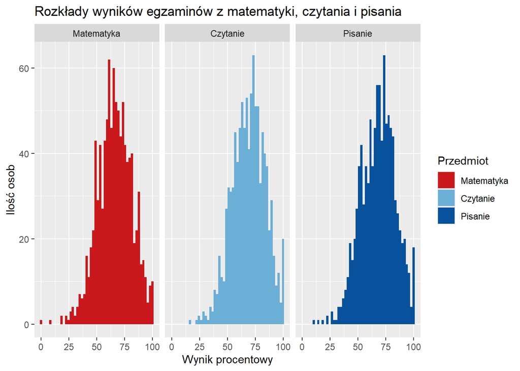

```r
df %>%

  pivot_longer(cols = c('math.score', 'reading.score', 'writing.score'),
               names_to = "subject",
               values_to = "score") %>%

  mutate(subject = factor(
    subject,
    levels = c("math.score", "reading.score", "writing.score"),
    labels = c("Matematyka", "Czytanie", "Pisanie")
  )) %>%

  ggplot(aes(x = score, fill = subject)) +
    geom_histogram(bins = 50) +
    facet_wrap(~subject) +
    labs(title = "Rozkłady wyników egzaminów z matematyki, czytania i pisania",
         x = "Wynik procentowy",
         y = "Ilość osob",
         fill = "Przedmiot") +
    scale_fill_manual(values = c("#CB181D", "#6BAED6", "#08519C"))
```

**Komentarz: Wykresy pokazują, że rozkłady wyników dla wszystkich trzech przedmiotów są w przybliżeniu normalne (mają kształt dzwonów) i mają po jednej dominującej wartości. Widać jednak pewne różnice – rozkład wyników z matematyki jest lekko przesunięty w stronę niższych wartości, podczas gdy rozkłady wyników z czytania i pisania skupiają się wokół wyższych wartości.**

## Zadanie 2

Czy istnieje zauważalna różnica w wynikach między uczniami i uczennicami?

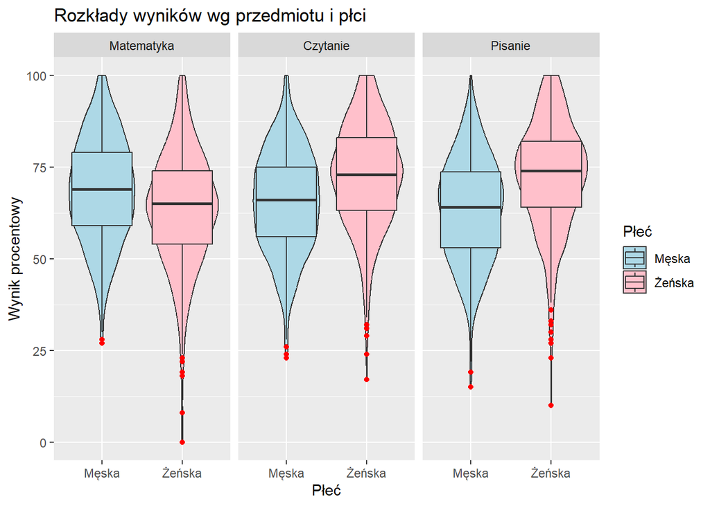

```r
df %>%

  pivot_longer(cols = c('math.score', 'reading.score', 'writing.score'),
               names_to = "subject",
               values_to = "score") %>%

  mutate(subject = factor(
    subject,
    levels = c("math.score", "reading.score", "writing.score"),
    labels = c("Matematyka", "Czytanie", "Pisanie")
  )) %>%

  mutate(gender = factor(
    gender,
    levels = c("male", "female"),
    labels = c("Męska", "Żeńska")
  )) %>%

  ggplot(aes(x = gender, y = score, fill = gender)) +
    geom_violin() +
    geom_boxplot(outlier.color = "red") +
    facet_wrap(~ subject) +
    labs(title = "Rozkłady wyników wg przedmiotu i płci",
         x = "Płeć",
         y = "Wynik procentowy",
         fill = "Płeć") +
    scale_fill_manual(values = c("lightblue", "pink"),
                      labels = c("Męska", "Żeńska"))
```

**Komentarz: Tak – istnieje zauważalna różnica w wynikach między uczniami i uczennicami. W przypadku matematyki wyniki są zbliżone, z nieznacznie wyższymi wynikami uczniów, z kolei w przypadku czytania i pisania uczennice osiągają wyraźnie wyższe wyniki.**

## Zadanie 3

Czy uczniowie, którzy ukończyli kurs przygotowawczy, osiągają lepsze wyniki niż pozostali?

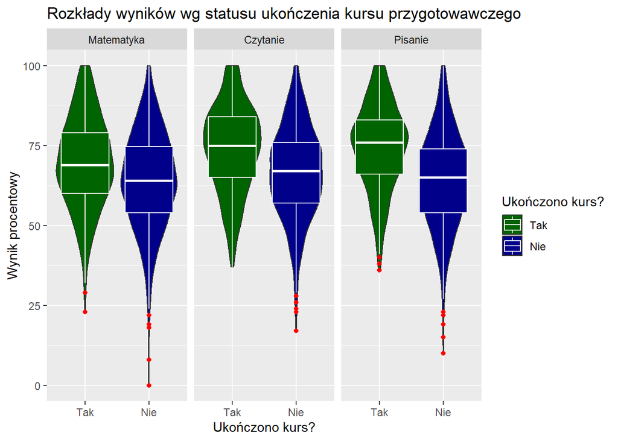

```r
df %>%

  pivot_longer(cols = c('math.score', 'reading.score', 'writing.score'),
               names_to = "subject",
               values_to = "score") %>%

  mutate(subject = factor(
    subject,
    levels = c("math.score", "reading.score", "writing.score"),
    labels = c("Matematyka", "Czytanie", "Pisanie")
  )) %>%

  mutate(test.preparation.course = factor(
    test.preparation.course,
    levels = c("completed", "none"),
    labels = c("Tak", "Nie")
  )) %>%

  ggplot(aes(x = test.preparation.course, y = score, fill = test.preparation.course)) +
    geom_violin() +
    geom_boxplot(outlier.color = "red", color = "white") +
    facet_wrap(~ subject) +
    labs(title = "Rozkłady wyników wg statusu ukończenia kursu przygotowawczego",
         x = "Ukończono kurs?",
         y = "Wynik procentowy",
         fill = "Ukończono kurs?") +
    scale_fill_manual(values = c("darkgreen", "darkblue"),
                      labels = c("Tak", "Nie"))
```

**Komentarz: Tak – uczniowie, którzy ukończyli kurs przygotowawczy, osiągają z każdego przedmiotu wyraźnie lepsze wyniki, niż ci, którzy go nie ukończyli. Różnica między wynikami jest największa dla pisania i najmniejsza dla matematyki.**

## Zadanie 4

Jaki jest związek między poziomem wykształcenia rodziców a średnimi wynikami uczniów?

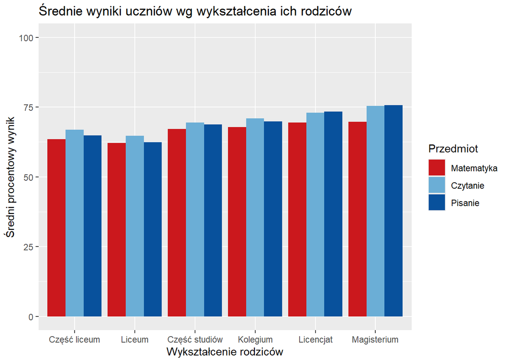

```r
df %>%

  group_by(parental.level.of.education) %>%
  summarise(mean_math_score = mean(math.score),
            mean_reading_score = mean(reading.score),
            mean_writing_score = mean(writing.score)) %>%

  pivot_longer(cols = c("mean_math_score", "mean_reading_score", "mean_writing_score"),
               names_to = "subject",
               values_to = "mean_score") %>%

  mutate(parental.level.of.education = factor(
    parental.level.of.education,
    levels = c("some high school",
               "high school",
               "some college",
               "associate's degree",
               "bachelor's degree",
               "master's degree"),
    labels = c("Część liceum",
               "Liceum",
               "Część studiów",
               "Kolegium",
               "Licencjat",
               "Magisterium")
  )) %>%

  ggplot(aes(x = parental.level.of.education, y = mean_score, fill = subject)) +
    geom_col(position = "dodge") +
    ylim(0, 100) +
    labs(title = "Średnie wyniki uczniów wg wykształcenia ich rodziców",
         x = "Wykształcenie rodziców",
         y = "Średni procentowy wynik",
         fill = "Przedmiot") +
    scale_fill_manual(values = c("#CB181D", "#6BAED6", "#08519C"),
                      labels = c("Matematyka", "Czytanie", "Pisanie"))
```

**Komentarz: Istnieje wyraźny, pozytywny związek między poziomem wykształcenia rodziców a średnimi wynikami uczniów, ich dzieci.**

**Wykres pokazuje, że im wyższy jest poziom wykształcenia rodziców, tym wyższe są średnie wyniki osiągane przez uczniów we wszystkich trzech przedmiotach. Najwiekszą różnicę w wynikach widać w przypadku pisania, a najmniejszą w przypadku matematyki.**

**Zaskakujące jest jednak to, że dzieci osób, które NIE ukończyły liceum, uzyskują ze wszystkiego lepsze wyniki od dzieci osób, które ukończyły liceum.**

## Zadanie 5

Czy płeć i wykształcenie rodzica wpływa na wynik z matematyki?

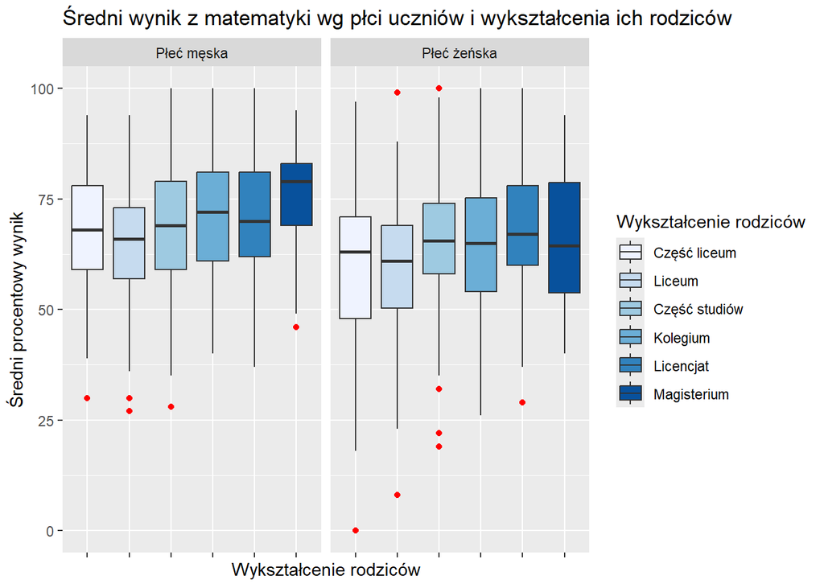

```r
df %>%

  mutate(parental.level.of.education = factor(
    parental.level.of.education,
    levels = c("some high school",
               "high school",
               "some college",
               "associate's degree",
               "bachelor's degree",
               "master's degree"),
    labels = c("Część liceum",
               "Liceum",
               "Część studiów",
               "Kolegium", # nie mogłam znaleźć dobrego odpowiednika po polsku
               "Licencjat",
               "Magisterium")
  )) %>%

  mutate(gender = factor(
    gender,
    levels = c("male", "female"),
    labels = c("Płeć męska", "Płeć żeńska")
  )) %>%

  ggplot(aes(x = parental.level.of.education, y = math.score, fill = parental.level.of.education)) +
    geom_boxplot(outlier.color = "red") +
    facet_wrap(~ gender) +
    labs(title = "Średni wynik z matematyki wg płci uczniów i wykształcenia ich rodziców",
         x = "Wykształcenie rodziców",
         y = "Średni procentowy wynik",
         fill = "Wykształcenie rodziców") +
    theme(axis.text.x = element_blank()) +
    scale_fill_manual(values = c("#EFF3FF", "#C6DBEF", "#9ECAE1", "#6BAED6", "#3182BD", "#08519C"))
```

**Komentarz: Ogólnie, tak – na wynik z matematyki wpływa zarówno płeć ucznia, jak i wykształcenie jego rodziców, nie mniej jednak nie jest to aż tak silna korelacja, jak na poprzednim wykresie.**

**W obydwu grupach płciowych widać, że wyższy poziom wykształcenia rodziców średnio przekłada się na wyższe wyniki ich dzieci, uczniów.**

**Nie mniej jednak, nie obowiązuje to przy zmianie poziomu edukacji z “części liceum” na “liceum” i zaskakujące jest też to, że o ile wykształcenie magisterskie rodziców ucznia znacząco podnosi jego wynik z tego egzaminu, to w przypadku uczennic wpływa na ten wynik negatywnie, obniżając go.**

**Ponadto, uczniowie osiągają lepsze wyniki z matematyki niż uczennice na każdym poziomie wykształcenia rodziców.**

## Zadanie 6

Czy istnieje zależność między wynikami z matematyki a wynikami z czytania lub pisania?

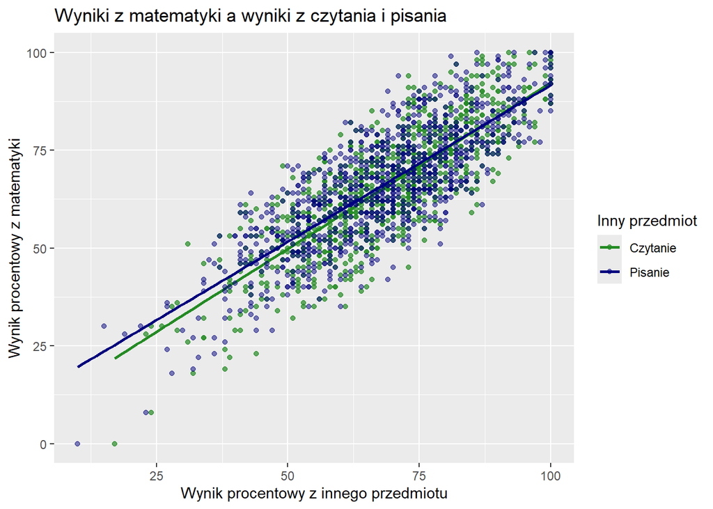

```r
df %>%

  ggplot() +
    geom_point(aes(x=reading.score,
                   y=math.score,
                   color="Czytanie"),
               alpha=0.7) +
    geom_smooth(aes(x=reading.score,
                    y=math.score,
                    color="Czytanie"),
                method="lm",
                se=FALSE) +
    geom_point(aes(x=writing.score,
                   y=math.score,
                   color="Pisanie"),
               alpha=0.5) +
    geom_smooth(aes(x=writing.score,
                    y=math.score,
                    color="Pisanie"),
                method="lm",
                se=FALSE) +
    labs(title = "Wyniki z matematyki a wyniki z czytania i pisania",
         y = "Wynik procentowy z matematyki",
         x = "Wynik procentowy z innego przedmiotu",
         color = "Inny przedmiot") +
    scale_color_manual(values = c("Czytanie"="forestgreen", "Pisanie"="navy"))
```

**Komentarz: Tak – istnieje silna, pozytywna korelacja między wynikami z matematyki a wynikami z czytania lub pisania. Wykres (wraz z prostymi najlepszego dopasowania) pokazuje, że punkty układają się wzdłuż rosnących linii, niemal pokrywających się ze sobą dla czytania i pisania.**